# Richard Safran

## Student ID: 998862635

# Assignment 3

The US Department of Agriculture publishes price estimates for fruits and vegetables [online](https://www.ers.usda.gov/data-products/fruit-and-vegetable-prices/fruit-and-vegetable-prices/). The most recent estimates are based on a 2013 survey of US retail stores.

The estimates are provided as a collection of MS Excel files, with one file per fruit or vegetable. The `assignment3_data.zip` file contains the fruit and vegetable files in the directories `fruit` and `vegetables`, respectively.

## Exercise 1.1. : Use pandas to extract the "Fresh" row(s) from the **fruit** Excel files. Combine the data into a single data frame. Your data frame should look something like this:

| type | food | form | price_per_lb | yield | lb_per_cup | price_per_cup |
| --- | --- | --- | --- | --- | --- | --- |
| fruit | watermelon | Fresh1 | 0.333412 | 0.52 | 0.330693 | 0.212033 |
| fruit | cantaloupe | Fresh1 | 0.535874 | 0.51 | 0.374786 | 0.3938 |
| vegetables | onions | Fresh1 | 1.03811 | 0.9 | 0.35274 | 0.406868 |
| ... |  |  |  |  |  |  |

It's okay if the rows and columns of your data frame are in a different order. These modules are especially relevant:

- [`str` methods](https://docs.python.org/2/library/stdtypes.html#string-methods)
- [`os`](https://docs.python.org/2/library/os.html)
- [`os.path`](https://docs.python.org/2/library/os.path.html)
- [pandas](http://pandas.pydata.org/pandas-docs/stable/): `read_excel()`, `concat()`, `.fillna()`, `.str`, plotting methods

Ask questions and search the documentation/web to find the functions you need.

```python
import os
import pandas as pd
import os.path

#Obtain the pathway to the documents
path = "/Users/Ricky/Desktop/STA 141b/HW/Assignment 3/assignment3_data/"
type_path_f = path + "fruit/" #Establish the intial pathway into the right folder.
files_name_f = os.listdir(type_path_f) #List all the documents inside the directory.
files_name_xlsx_f = [f for f in files_name_f if f.endswith("xlsx")] #Only keep all the excel documents and discard the rest.

list_items_f = [['type','food']] #Initialize a dataframe that will hold all the type and name of the foods recorded.
df_f = pd.DataFrame() #Initialize a dataframe that will hold all the values for the foods recorded.

for h in range(len(files_name_xlsx_f)):
    """
    For loop goes through each of the excel documents in the directory and scrapes them for the relevant information.
    """
    food_specific_f = type_path_f + files_name_xlsx_f[h] #identify the pathway of the individual fruit and grab the whole file.

    if files_name_xlsx_f[h] == "pineapple.xlsx":
        """
        Pineapple spreadsheet had the extra two columns which prevented it from being counted. Deleted the extra columns before preceding.
        """
        read_file_f = pd.read_excel(food_specific_f, header = 1) #Drop values that have NA
        del read_file_f["Unnamed: 7"]; del read_file_f["Unnamed: 8"] #Del the col with all NA so that the important info does not get deleted when dropping NA
        read_file_f = read_file_f.dropna() #Drop all the columns not filled with information

    else:
        read_file_f = pd.read_excel(food_specific_f, header = 1).dropna() #Drop values that have NA

    read_file_f = read_file_f[read_file_f.iloc[:,0].str.endswith(("Fresh1", "Fresh1 "))] #Find value that ends with fresh1. 2 variants so both included
    del read_file_f["Unnamed: 2"]; del read_file_f["Unnamed: 5"] #Del the cols not needed that just contained the units
    df_f = df_f.append(read_file_f, ignore_index = True)[read_file_f.columns.tolist()] #append to the end and add column names.

    if not read_file_f.empty:
        """
        grab the name of the fruit but only if it had values that were appended to the main data above. Thus, look to see if the current index had any data after I removed the NAs. If no data then skip, if so then add to a seperate data frame that conains type and food.
        """
        item_name_f = ['fruit', files_name_xlsx_f[h][:-5]]
        list_items_f.append(item_name_f)

type_and_food_df_f = pd.DataFrame(list_items_f[1:],columns=list_items_f[0]) #Freeze the column positions when creating the dataframe
df_f = df_f.dropna(1) #Drop the two empty columns at the end
final_df_f = pd.concat([type_and_food_df_f, df_f], axis=1, join='inner') #Combine the two data frames into a master set
final_df_f = final_df_f.rename(index = str, columns={"type":"type","food":"food","Form":"form","Average retail price ":"price_per_lb","Preparation":"yield","Size of a ":"lb_per_cup","Average price":"price_per_cup"})
final_df_f.head()
```

|  | type | food | form | price_per_lb | yield | lb_per_cup | price_per_cup |
| --- | --- | --- | --- | --- | --- | --- | --- |
| 0 | fruit | apples | Fresh1 | 1.56752 | 0.9 | 0.242508 | 0.422373 |
| 1 | fruit | apricots | Fresh1 | 3.04007 | 0.93 | 0.363763 | 1.1891 |
| 2 | fruit | bananas | Fresh1 | 0.566983 | 0.64 | 0.330693 | 0.292965 |
| 3 | fruit | blackberries | Fresh1 | 5.77471 | 0.96 | 0.31967 | 1.92292 |
| 4 | fruit | blueberries | Fresh1 | 4.73462 | 0.95 | 0.31967 | 1.59318 |

## Exercise 1.2. : Reuse your code from exercise 1.1 to extract the "Fresh" row(s) from the **vegetable** Excel files.

Does your code produce the correct prices for tomatoes? If not, why not? Do any other files have the same problem as the tomatoes file?

You don't need to extract the prices for these problem files. However, make sure the prices are extracted for files like asparagus that don't have this problem.

```python
#Obtain the pathway to the documents
type_path_v = path + "vegetables/" #Establish the intial pathway into the right folder.
files_name_v = os.listdir(type_path_v) #List all the documents inside the directory.
files_name_xlsx_v = [e for e in files_name if e.endswith("xlsx")] #Only keep all the excel documents and discard the rest.

list_items_v = [['type','food']] #Initialize a dataframe that will hold all the type and name of the foods recorded.
df_v = pd.DataFrame() #Initialize a dataframe that will hold all the values for the foods recorded.

for h in range(len(files_name_xlsx_v)):
    """
    For loop that goes through each of the excel documents in the directory and scrapes them for the relevant information.
    """

    food_specific_v = type_path_v + files_name_xlsx_v[h] #identify the pathway of the vegetable and grab the whole excel file.
    read_file_v = pd.read_excel(food_specific_v, header = 1).dropna() #Drop values that have NA
    read_file_v = read_file_v[read_file_v.iloc[:,0].str.endswith(('Fresh1', 'Fresh1 '))] #Find value that ends with fresh
    del read_file_v["Unnamed: 2"]; del read_file_v["Unnamed: 5"] #Del the col not needed
    df_v = df_v.append(read_file_v, ignore_index = True)[read_file_v.columns.tolist()] #append the values for the given vegtable to the end

    if not read_file_v.empty:
        """
        Grab the name of the vegetable but only if it had values that were appended to the main data above. Thus, look to see if the current index had any data after I removed the NAs. If no data then skip, if so then add to a seperate data frame that conains type and food.
        """
        item_name_v = ['vegetables', files_name_xlsx_v[h][:-5]]
        list_items_v.append(item_name_v)

type_and_food_df_v = pd.DataFrame(list_items_v[1:],columns=list_items_v[0]) #Transform the type and food columns into a dataframe. Obtain the headings.
df_v = df_v.dropna(1) #Drop the additional columns that contained information found in some of the excel documents. What is left is all the data for each of the fruit.
final_df_v = pd.concat([type_and_food_df_v, df_v], axis=1, join='inner') #Combine the two dataframes into a whole list. Made sure that only vegtables that had data were added to the type and food dataset. Thus, same dimensions and all values are aligned.
#df.rename(index=str, columns={"A": "a", "B": "c"})
final_df_v = final_df_v.rename(index = str, columns={"type":"type","food":"food","Form":"form","Average retail price ":"price_per_lb","Preparation":"yield","Size of a ":"lb_per_cup","Average price":"price_per_cup"}) #Rename the dataset to the appropriate value.
final_df_v.head()
```

|  | type | food | form | price_per_lb | yield | lb_per_cup | price_per_cup |
| --- | --- | --- | --- | --- | --- | --- | --- |
| 0 | vegetables | acorn_squash | Fresh1 | 1.172248 | 0.458554 | 0.451948 | 1.15536 |
| 1 | vegetables | artichoke | Fresh1 | 2.213050 | 0.375309 | 0.385809 | 2.27497 |
| 2 | vegetables | asparagus | Fresh1 | 3.213494 | 0.493835 | 0.396832 | 2.58227 |
| 3 | vegetables | avocados | Fresh1 | 2.235874 | 0.740753 | 0.31967 | 0.964886 |
| 4 | vegetables | brussels_sprouts | Fresh1 | 2.763553 | 1.06 | 0.341717 | 0.890898 |

My code does not register the irregularities mentioned above with vegetables like tomatoes, carrots, cauliflower, celery, or brocoli. This is because these items have multiple variants underneath the fresh label. Consequently, my code only looks for a row that ends with fresh1 and then proceeds to check for the values in that row after eliminating the NAs. Since the informaiton for these vegetbales are stored in the subsequent rows with no information in the fresh row, the row gets deleted and the information located in the following area gets overlooked. To fix this I would want to write a function that checks the subsequent row after fresh and looks to see if the tab character was before the next type of food. If so then I would have the function return the values of interest and if not than break the function. Additionally, I would have to account for odd cases such as cabbage where 2 different variants are lister in subsequent rows with the freh tag for both of them.

Examining the rest of my code everything else is accurate.

## Exercise 1.3. : Remove rows without a price from the vegetable data frame and then combine the fruit and vegetable data frames. Make sure all columns of numbers are numeric (not strings).

Due to format of my function, fruits and vegetable rows that contained any NAs were deleted. As a result, all of the values in my prior two databases for fruits and vegetables contained prices. Thus, I did not have to remove any rows without a price.

```python
#create final_data_set
final_data_set = final_df_f.append(final_df_v, ignore_index = True)

#Set the columns for the last 4 columns equal to the float type to incorporate the decimal places.
final_data_set[['price_per_lb', 'yield','lb_per_cup','price_per_cup']] = final_data_set[['price_per_lb', 'yield','lb_per_cup','price_per_cup']].astype(float)
print final_data_set.dtypes
final_data_set.head()
```

```
type              object
food              object
form              object
price_per_lb     float64
yield            float64
lb_per_cup       float64
price_per_cup    float64
dtype: object
```

|  | type | food | form | price_per_lb | yield | lb_per_cup | price_per_cup |
| --- | --- | --- | --- | --- | --- | --- | --- |
| 0 | fruit | apples | Fresh1 | 1.567515 | 0.90 | 0.242508 | 0.422373 |
| 1 | fruit | apricots | Fresh1 | 3.040072 | 0.93 | 0.363763 | 1.189102 |
| 2 | fruit | bananas | Fresh1 | 0.566983 | 0.64 | 0.330693 | 0.292965 |
| 3 | fruit | blackberries | Fresh1 | 5.774708 | 0.96 | 0.319670 | 1.922919 |
| 4 | fruit | blueberries | Fresh1 | 4.734622 | 0.95 | 0.319670 | 1.593177 |

**Exercise 1.4.** Discuss the questions below (a paragraph each is sufficient). Use plots to support your ideas.

- What kinds of fruits are the most expensive (per pound)? What kinds are the least expensive?
- How do the price distributions compare for fruit and vegetables?
- Which foods are the best value for the price?
- What's something surprising about this data set?
- Which foods do you expect to provide the best combination of price, yield, and nutrition? A future assignment may combine this data set with another so you can check your hypothesis.

## What kinds of fruits are the most expensive (per pound)? What kinds are the least expensive?

```
Most expensive fruit per pound is raspberries at 6.98 per lb.
Least expensive fruit per pound is: watermelon at 0.33 per lb.
```

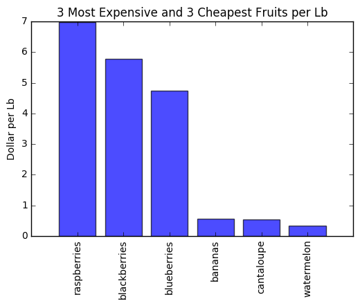

```python
fruits = final_data_set[final_data_set['type'] == 'fruit']
fruits = fruits.set_index('food')

#Max
expensive = fruits['price_per_lb'].argmax()
cost_exp = round(fruits['price_per_lb'].max(),2)
cheap = fruits['price_per_lb'].argmin()
cost_che = round(fruits['price_per_lb'].min(),2)
print "Most expensive fruit per pound is", expensive, "at", cost_exp, "per lb."
print "Least expensive fruit per pound is:", cheap, "at", cost_che, "per lb."

#Top three and bottom three most expensive fruits in a single database
expensive_fruits = fruits.sort_values('price_per_lb', ascending=False).head(3)
cheap_fruits = fruits.sort_values('price_per_lb', ascending=True).head(3)
extreme_fruits = expensive_fruits.append(cheap_fruits).sort_values('price_per_lb', ascending=False)

#Set up the x axis values with names saved to a list and a position for the inital graph.
objects = extreme_fruits.index.values.tolist()
y_pos = np.arange(len(objects))

#Plot the data
plt.bar(y_pos, extreme_fruits['price_per_lb'], align='center', alpha=0.7)

#Set up the graphs
plt.xticks(y_pos, objects, rotation = 'vertical')
plt.ylabel('Dollar per Lb')
plt.title('3 Most Expensive and 3 Cheapest Fruits per Lb')
plt.show()
```

Based on my findings raspberries are the most expensive fruit per lb at 6.98/lb while watermellon is the cheapest at 0.33/lb.

## How do the price distributions compare for fruit and vegetables?

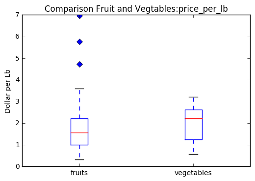

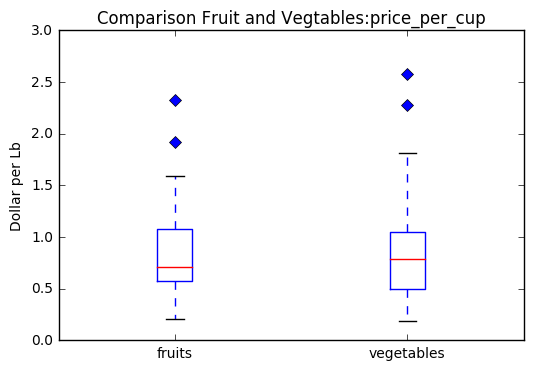

```python
import matplotlib.pyplot as plt
import numpy as np

veggies = final_data_set[final_data_set['type'] == 'vegetables']
x_labels = ['fruits','vegetables']
pos = np.arange(len(x_labels))+1

measure = ['price_per_lb','price_per_cup']

for a in range(len(measure)):
    plt.boxplot([fruits[measure[a]],veggies[measure[a]]], 0, 'gD')
    plt.ylabel('Dollar per Lb')
    plt.xticks(pos, x_labels)
    plt.title('Comparison Fruit and Vegtables:'+ measure[a])
    plt.show()
```

Overall, vegtables will be on average more expensive than fruit no matter which measure an individual uses. However, there are specific fruits that are very dense and small that result in the highest price per lb. As a result, when purchasing vegetables an individual can expect to pay a relatively constant price per lb ranging across 2 or 3 dollars depending on the measure, while when purchasing fruits the individual will pay typically in a range of 3 1/2 dollars buying price per lb and a more consistent 1 1/2 dollars price per cup, exluding berries which are all around expensive.

## Which foods are the best value for the price?

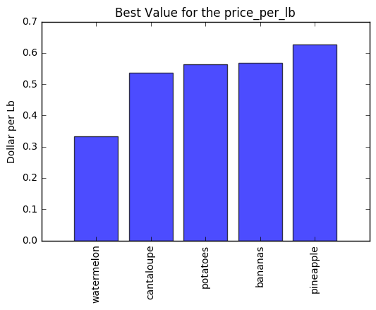

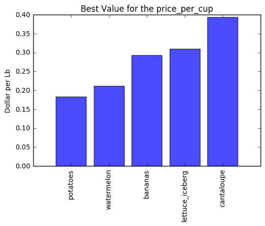

```python
for a in range(len(measure)):
    cheap_price_per = final_data_set.sort_values(measure[a], ascending=True).head(5)
    cheap_price_per = cheap_price_per.set_index('food')

    objects_che = cheap_price_per.index.values.tolist()
    y_pos_che = np.arange(len(objects_che))

    #Plot the data
    plt.bar(y_pos_che, cheap_price_per[measure[a]], align='center', alpha=0.7)

    #Set up the graphs
    plt.xticks(y_pos_che, objects_che, rotation = 'vertical')
    plt.ylabel('Dollar per Lb')
    plt.title('Best Value for the ' + measure[a])
    plt.show()
```

Based on my above findings four of the five best value foods are considered the best value across both measurements of price per cup and price per lb. Therefore, if an individual wanted to get the most of their money the should consider buying potatoes, watermlon, bananas, and cantaloupe. Each of these will provide a large amount of food at a small price per pound and food per cup.

## What's something surprising about this data set?

Somethings that I were suprised were the incorrect notations on the spreadsheet, such as there being an extra space for blackberries after fresh1. While this might not seem like a big deal for the inputter a simple mistake such as an extra space caused an extra 20 minutes of deducing followed by a couple lines of code. In regards to the actual results I was suprised by how expensive berries were. I knew that all types of berries were epxensive, but just comparing them to other fruits really puts into perspective how bad a deal buying berries are. Additionally, I was shocked by how cheap watermelon was. I love watermelon but I hate buying it at the store because it appears expensive. However, it never occured to me to compare food across weight or cup size which when done makes watermelon the cheapest food available in price per lb and second cheapest in price per cup. When I compared fruits and vegetables I was somewhat suprised that vegetables were on average more expensive than fruit. Vegtables for me always seem like a staple food while fruit is more of a delicacy. Examining the data I learned this was only true for certain types of fruits while almost all vegtables were within the expected pricing range.

## Which foods do you expect to provide the best combination of price, yield, and nutrition? A future assignment may combine this data set with another so you can check your hypothesis.

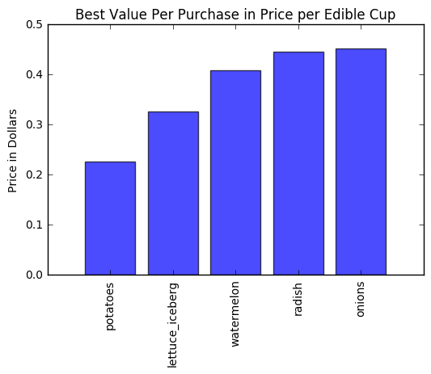

[output not shown]

```python
final_data_set['Price_per_cup_edible'] = final_data_set['price_per_cup']/final_data_set['yield']

cheap_price_per_val = final_data_set.sort_values('Price_per_cup_edible', ascending=True).head(5)
cheap_price_per_val = cheap_price_per_val.set_index('food')

objects_che_val = cheap_price_per_val.index.values.tolist()
y_pos_che_val = np.arange(len(objects_che_val))

#Plot the data
plt.bar(y_pos_che_val, cheap_price_per_val['Price_per_cup_edible'], align='center', alpha=0.7)

#Set up the graphs
plt.xticks(y_pos_che_val, objects_che_val, rotation = 'vertical')
plt.ylabel('Price in Dollars')
plt.title('Best Value Per Purchase in Price per Edible Cup')
plt.show()
final_data_set.head(5)
```

To figure out the best combination of price and yield I created a new column that took price_per_cup and dividied by yield. This calculation penalized foods with low yields which do not have a lot of edible portions and rewarded food that yielded a lot. The result was a slight reshuffling of the food items with potatoes solidly the best value food, followed by iceberg lettuce, watermelon (which got penalized for a yield of aroudn .5), radish and then onions.

My above calculation did not take into account the nutritional elements of these food since I did not have data. Therefore, if I were to obtain the nutritional data I would combine that information with the price_per_cup_edible column to obtain an overall value. The combination between these factors could be adjusted by weights to provide extra emphasis on certain areas. For instance if an individual wanted to be cost effective they would weight price_per_cup_edible as twice as important as the nutritional part.

My hypothesis would be that the more nutritional benefits a food item provides the more expensive that item would be. This is due to there being a higher demand among nutritionally minded individuals. Due to the higher demand and more intensive growth demands of nutritional food items I would believe that these food items would be the most expensive. Meanwhile, the opposite is true for non-nutritious food items that were easy to grow and are low demand resulting in these typicall having the lowest price_per_cup.